# 1.3 与数据有关的对象

授课教师: 李哲源，河南大学数学与统计学院

最后修改日期: 2023-02-20

R软件： 初学**R**语言可以不用安装该软件，不妨试试在线版本：https://rdrr.io/snippets/。

R程序文件：创建一个后缀名为”.R”的文件，比如”example.R”，然后用普通的记事本（notepad）打开。或者，安装一个更高级的记事本（notepad++）以获得更好的编程体验。

# 1.3.1 纯量（长度为1的向量）

## 1.3.1-1 计算器

简单的四则运算（加、减、乘、除）和幂次运算。

```r
1 + 2 * 3 + 4 / 5 + 6 ^ 2
```

```
## [1] 43.8
```

使用内置常数，如圆周律。

```r
## 半径为10的圆的周长
2 * pi * 10
```

```
## [1] 62.83185
```

函数运算。

```r
sqrt(2)
```

```
## [1] 1.414214
```

```r
2 ^ (1/3)
```

```
## [1] 1.259921
```

```r
exp(1)
```

```
## [1] 2.718282
```

```r
log(10)
```

```
## [1] 2.302585
```

逻辑运算。

```r
3 == 5
```

```
## [1] FALSE
```

## 1.3.1-2 纯量类型与变量赋值

纯量类型包括：实数、复数、字符串、逻辑值。

作为一门编程软件（不止是一个计算器），**R**可以设置和操作变量。

```r
## 实数（包括整数）
n <- 30; a <- 59.9; b <- -3.8

## 复数
c <- 3 + 4i

## 字符串
name <- "XueYi"

## 逻辑值
L <- TRUE
```

## 1.3.1-3 变量类型之间的相互转换

```r
x <- 3
y <- as.character(x)
y
```

```
## [1] "3"
```

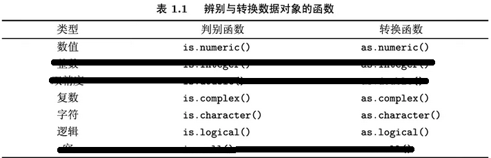

注：这些函数同样适用于下面要介绍的向量。

# 1.3.2 向量

## 1.3.2-1 常见的创建方法

从元素创建向量。

```r
x <- c(10.4, 5.6, 3.1, 6.4, 21.7); x
```

```
## [1] 10.4  5.6  3.1  6.4 21.7
```

```r
y <- c(x, 0, x); y
```

```
##  [1] 10.4  5.6  3.1  6.4 21.7  0.0 10.4  5.6  3.1  6.4 21.7
```

`length`函数可以返回向量中元素的个数（通俗意义上的“向量长度”）。

```r
length(x)
```

```
## [1] 5
```

```r
length(y)
```

```
## [1] 11
```

生成整数序列。

```r
1:10
```

```
##  [1]  1  2  3  4  5  6  7  8  9 10
```

```r
10:1
```

```
##  [1] 10  9  8  7  6  5  4  3  2  1
```

为避免歧义，不要吝啬括号的使用。

```r
-2:5  ## 建议写为(-2):5
```

```
## [1] -2 -1  0  1  2  3  4  5
```

```r
-(2:5)
```

```
## [1] -2 -3 -4 -5
```

生成一般的等差数列。

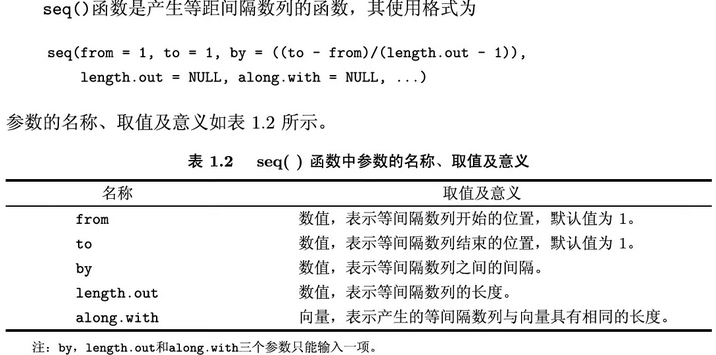

```r
seq(0, 1, length.out = 11)
```

```
##  [1] 0.0 0.1 0.2 0.3 0.4 0.5 0.6 0.7 0.8 0.9 1.0
```

```r
seq(1, 9, by = 2)
```

```
## [1] 1 3 5 7 9
```

```r
seq(1, 9, by = pi)
```

```
## [1] 1.000000 4.141593 7.283185
```

```r
seq(1, 6, by = 3)
```

```
## [1] 1 4
```

```r
seq(length.out = 10)
```

```
##  [1]  1  2  3  4  5  6  7  8  9 10
```

```r
seq(0, 1, along.with = 1:11)
```

```
##  [1] 0.0 0.1 0.2 0.3 0.4 0.5 0.6 0.7 0.8 0.9 1.0
```

按照一定规律重复向量的元素。

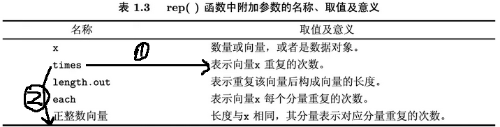

```r
rep(1:4, times = 2)
```

```
## [1] 1 2 3 4 1 2 3 4
```

```r
rep(1:4, times = c(1, 2, 2, 3))
```

```
## [1] 1 2 2 3 3 4 4 4
```

```r
rep(1:4, each = 2)
```

```
## [1] 1 1 2 2 3 3 4 4
```

```r
rep(1:4, length.out = 10)
```

```
##  [1] 1 2 3 4 1 2 3 4 1 2
```

## 1.3.2-2 下标的使用

```r
x <- c(1, 4, 7); x[2]
```

```
## [1] 4
```

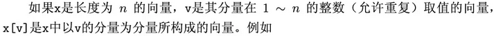

```r
x <- 10:20

x[c(1, 3, 5, 9)]
```

```
## [1] 10 12 14 18
```

```r
x[1:5]
```

```
## [1] 10 11 12 13 14
```

```r
x[c(1, 2, 3, 2, 1)]
```

```
## [1] 10 11 12 11 10
```

```r
c("a", "b", "c")[rep(c(2, 1, 3), times = 3)]
```

```
## [1] "b" "a" "c" "b" "a" "c" "b" "a" "c"
```

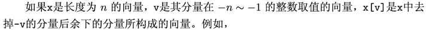

```r
x <- 10:20; x[-(1:5)]
```

```
## [1] 15 16 17 18 19 20
```

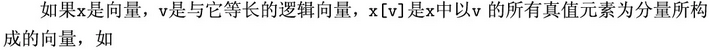

```r
x <- c(1, 4, 7)

x < 5
```

```
## [1]  TRUE  TRUE FALSE
```

```r
x[x < 5]
```

```
## [1] 1 4
```

## 1.3.2-3 增加新元素

在首尾增加新元素，可直接使用`c`函数。

```r
x <- 1:6; y <- 0:1
c(x, y)
```

```
## [1] 1 2 3 4 5 6 0 1
```

在中间添加新元素，可使用`append`函数。

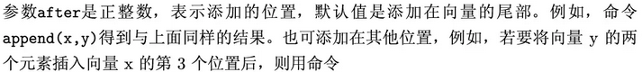

```r
x <- 1:6; y <- 0:1
append(x, y, after = 3)
```

```
## [1] 1 2 3 0 1 4 5 6
```

# 1.3.3 因子

## 1.3.3-1 名义因子变量

名义因子变量，一般由字符串向量转换而来。

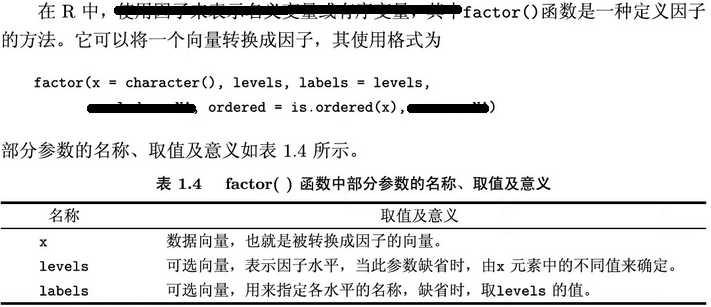

```r
## 字符串向量
sex <- c("Male", "Female", "Male", "Male", "Female")

## 有默认的因子水平排序，在字母表中F比M靠前
fsex1 <- factor(sex); fsex1
```

```
## [1] Male   Female Male   Male   Female
## Levels: Female Male
```

```r
## 自定义因子水平的顺序
fsex2 <- factor(sex, levels = c("Male", "Female")); fsex2
```

```
## [1] Male   Female Male   Male   Female
## Levels: Male Female
```

在创建因子变量时可对因子水平重命名。

```r
## 自定义因子水平的顺序，并重命名因子水平
fsex3 <- factor(sex, levels = c("Male", "Female"), labels = c("M", "F")); fsex3
```

```
## [1] M F M M F
## Levels: M F
```

## 1.3.3-2 区间因子变量

区间因子变量，一般是切割数值向量得到的。

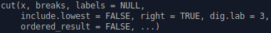

```r
## 数值向量
x <- rep(1:4, c(2, 1, 4, 3)); x
```

```
##  [1] 1 1 2 3 3 3 3 4 4 4
```

利用`breaks`参数具体地设置区间端点。

```r
cut(x, breaks = seq(0.5, 4.5, by = 1))
```

```
##  [1] (0.5,1.5] (0.5,1.5] (1.5,2.5] (2.5,3.5] (2.5,3.5] (2.5,3.5] (2.5,3.5]
##  [8] (3.5,4.5] (3.5,4.5] (3.5,4.5]
## Levels: (0.5,1.5] (1.5,2.5] (2.5,3.5] (3.5,4.5]
```

```r
cut(x, breaks = seq(0.5, 4.5, by = 1), include.lowest = TRUE)
```

```
##  [1] [0.5,1.5] [0.5,1.5] (1.5,2.5] (2.5,3.5] (2.5,3.5] (2.5,3.5] (2.5,3.5]
##  [8] (3.5,4.5] (3.5,4.5] (3.5,4.5]
## Levels: [0.5,1.5] (1.5,2.5] (2.5,3.5] (3.5,4.5]
```

```r
cut(x, breaks = seq(0.5, 4.5, by = 1), right = FALSE)
```

```
##  [1] [0.5,1.5) [0.5,1.5) [1.5,2.5) [2.5,3.5) [2.5,3.5) [2.5,3.5) [2.5,3.5)
##  [8] [3.5,4.5) [3.5,4.5) [3.5,4.5)
## Levels: [0.5,1.5) [1.5,2.5) [2.5,3.5) [3.5,4.5)
```

```r
cut(x, breaks = seq(0.5, 4.5, by = 1), include.lowest = TRUE, right = FALSE)
```

```
##  [1] [0.5,1.5) [0.5,1.5) [1.5,2.5) [2.5,3.5) [2.5,3.5) [2.5,3.5) [2.5,3.5)
##  [8] [3.5,4.5] [3.5,4.5] [3.5,4.5]
## Levels: [0.5,1.5) [1.5,2.5) [2.5,3.5) [3.5,4.5]
```

利用`breaks`参数简单地设置区间个数。

```r
cut(x, breaks = 3)
```

```
##  [1] (0.997,2] (0.997,2] (0.997,2] (2,3]     (2,3]     (2,3]     (2,3]
##  [8] (3,4]     (3,4]     (3,4]
## Levels: (0.997,2] (2,3] (3,4]
```

```r
cut(x, breaks = 3, include.lowest = TRUE)
```

```
##  [1] [0.997,2] [0.997,2] [0.997,2] (2,3]     (2,3]     (2,3]     (2,3]
##  [8] (3,4]     (3,4]     (3,4]
## Levels: [0.997,2] (2,3] (3,4]
```

```r
cut(x, breaks = 3, right = FALSE)
```

```
##  [1] [0.997,2) [0.997,2) [2,3)     [3,4)     [3,4)     [3,4)     [3,4)
##  [8] [3,4)     [3,4)     [3,4)
## Levels: [0.997,2) [2,3) [3,4)
```

```r
cut(x, breaks = 3, include.lowest = TRUE, right = FALSE)
```

```
##  [1] [0.997,2) [0.997,2) [2,3)     [3,4]     [3,4]     [3,4]     [3,4]
##  [8] [3,4]     [3,4]     [3,4]
## Levels: [0.997,2) [2,3) [3,4]
```

## 1.3.3-3 有序因子变量

如果对因子水平的排序有一定实际意义，而不是纯粹的主观意愿，可以规定因子水平的顺序。

```r
banji <- c("三", "二", "二", "一", "三")
factor(banji, levels = c("一", "二", "三"), ordered = TRUE)
```

```
## [1] 三 二 二 一 三
## Levels: 一 < 二 < 三
```

```r
x <- rep(1:4, c(2, 1, 4, 3))
cut(x, breaks = seq(0.5, 4.5, by = 1), ordered_result = TRUE)
```

```
##  [1] (0.5,1.5] (0.5,1.5] (1.5,2.5] (2.5,3.5] (2.5,3.5] (2.5,3.5] (2.5,3.5]
##  [8] (3.5,4.5] (3.5,4.5] (3.5,4.5]
## Levels: (0.5,1.5] < (1.5,2.5] < (2.5,3.5] < (3.5,4.5]
```

## 1.3.3-4 快速生成简单的因子变量

**R**提供了一个有规律地生成因子变量的函数。

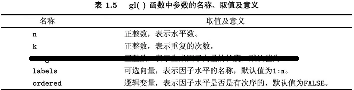

```r
gl(n = 3, k = 5, labels = c("I", "II", "III"))
```

```
##  [1] I   I   I   I   I   II  II  II  II  II  III III III III III
## Levels: I II III
```

## 1.3.3-5 因子变量的用途

因子变量一般用来分组计数（`table`），或执行一般的分组操作（`tapply`）。

```r
## 字符串向量
sex <- c("M", "F", "M", "M", "F")

## 自定义因子水平的顺序
fsex <- factor(sex, levels = c("M", "F"))

## 分组计数
table(fsex)
## fsex
## M F
## 3 2

## 分组操作
fenshu <- c(97, 92, 91, 82, 95)
tapply(fenshu, fsex, FUN = mean)
```

```
##    M    F
## 90.0 93.5
```

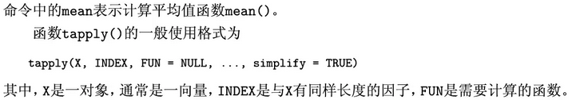

# 1.3.4 矩阵

矩阵和向量没有本质的存储差别。矩阵只比向量多了一个“维数”属性。

```r
x <- c(1, 2, 3, 11, 12, 13)

dim(x) <- c(2, 3); x
```

```
##      [,1] [,2] [,3]
## [1,]    1    3   12
## [2,]    2   11   13
```

```r
dim(x) <- NULL; x
```

```
## [1]  1  2  3 11 12 13
```

## 1.3.4-1 从元素生成矩阵

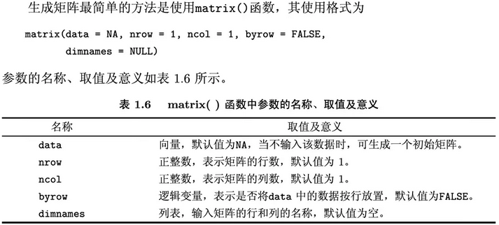

```r
x <- c(1, 2, 3, 11, 12, 13)

m1 <- matrix(x, nrow = 2, ncol = 3); m1
```

```
##      [,1] [,2] [,3]
## [1,]    1    3   12
## [2,]    2   11   13
```

```r
m2 <- matrix(x, nrow = 2, ncol = 3, byrow = TRUE); m2
```

```
##      [,1] [,2] [,3]
## [1,]    1    2    3
## [2,]   11   12   13
```

```r
## 无名列表
m3 <- matrix(x, nrow = 2, ncol = 3, byrow = TRUE,
             dimnames = list(c("r1", "r2"), c("c1", "c2", "c3")))
m3
```

```
##    c1 c2 c3
## r1  1  2  3
## r2 11 12 13
```

```r
## 有名列表
m4 <- matrix(x, nrow = 2, ncol = 3, byrow = TRUE,
             dimnames = list(row = c("r1", "r2"), col = c("c1", "c2", "c3")))
m4
```

```
##     col
## row  c1 c2 c3
##   r1  1  2  3
##   r2 11 12 13
```

生成纯零矩阵。

```r
matrix(0, nrow = 3, ncol = 4)
```

```
##      [,1] [,2] [,3] [,4]
## [1,]    0    0    0    0
## [2,]    0    0    0    0
## [3,]    0    0    0    0
```

生成对角矩阵（方阵）可使用`diag`函数。指明对角线元素即可。

```r
diag(c(1, 2, 3))
```

```
##      [,1] [,2] [,3]
## [1,]    1    0    0
## [2,]    0    2    0
## [3,]    0    0    3
```

单位矩阵（方阵）的生成也使用`diag`。

```r
diag(1, nrow = 4)
```

```
##      [,1] [,2] [,3] [,4]
## [1,]    1    0    0    0
## [2,]    0    1    0    0
## [3,]    0    0    1    0
## [4,]    0    0    0    1
```

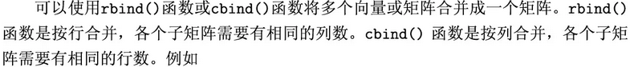

```r
X1 <- rbind(1:2, 101:102); X1
```

```
##      [,1] [,2]
## [1,]    1    2
## [2,]  101  102
```

```r
X2 <- cbind(1:2, 101:102); X2
```

```
##      [,1] [,2]
## [1,]    1  101
## [2,]    2  102
```

```r
cbind(X1, X2)
```

```
##      [,1] [,2] [,3] [,4]
## [1,]    1    2    1  101
## [2,]  101  102    2  102
```

```r
rbind(X1, X2)
```

```
##      [,1] [,2]
## [1,]    1    2
## [2,]  101  102
## [3,]    1  101
## [4,]    2  102
```

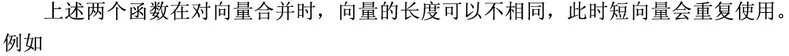

```r
rbind(11:14, 1:2)
```

```
##      [,1] [,2] [,3] [,4]
## [1,]   11   12   13   14
## [2,]    1    2    1    2
```

```r
## 常见操作是补0
X <- matrix(1:6, nrow = 2, ncol = 3)
cbind(rbind(X, 0), 0)
```

```
##      [,1] [,2] [,3] [,4]
## [1,]    1    3    5    0
## [2,]    2    4    6    0
## [3,]    0    0    0    0
```

## 1.3.4-2 与矩阵运算有关的函数和操作

获取矩阵的维数（行数 x 列数），或只是行数、列数。

```r
A <- matrix(1:12, nrow = 3, ncol = 4); A
```

```
##      [,1] [,2] [,3] [,4]
## [1,]    1    4    7   10
## [2,]    2    5    8   11
## [3,]    3    6    9   12
```

```r
dim(A)
```

```
## [1] 3 4
```

```r
nrow(A)
```

```
## [1] 3
```

```r
ncol(A)
```

```
## [1] 4
```

获取或更改矩阵的行、列名。

```r
dimnames(A)
## NULL

dimnames(A) <- list(1:3, 1:4)
A
```

```
##   1 2 3  4
## 1 1 4 7 10
## 2 2 5 8 11
## 3 3 6 9 12
```

```r
rownames(A)
```

```
## [1] "1" "2" "3"
```

```r
colnames(A)
```

```
## [1] "1" "2" "3" "4"
```

```r
rownames(A) <- c("r1", "r2", "r3")
colnames(A) <- c("c1", "c2", "c3", "c4")
A
```

```
##    c1 c2 c3 c4
## r1  1  4  7 10
## r2  2  5  8 11
## r3  3  6  9 12
```

```r
dimnames(A) <- NULL
A
```

```
##      [,1] [,2] [,3] [,4]
## [1,]    1    4    7   10
## [2,]    2    5    8   11
## [3,]    3    6    9   12
```

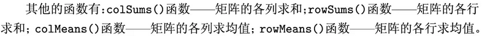

```r
rowSums(A)
```

```
## [1] 22 26 30
```

```r
colSums(A)
```

```
## [1]  6 15 24 33
```

```r
rowMeans(A)
```

```
## [1] 5.5 6.5 7.5
```

```r
colMeans(A)
```

```
## [1]  2  5  8 11
```

可以使用`row`和`col`函数获得元素的行、列指标。

```r
row(A)
```

```
##      [,1] [,2] [,3] [,4]
## [1,]    1    1    1    1
## [2,]    2    2    2    2
## [3,]    3    3    3    3
```

```r
col(A)
```

```
##      [,1] [,2] [,3] [,4]
## [1,]    1    2    3    4
## [2,]    1    2    3    4
## [3,]    1    2    3    4
```

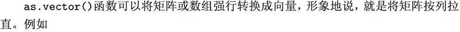

```r
as.vector(A)
```

```
##  [1]  1  2  3  4  5  6  7  8  9 10 11 12
```

## 1.3.4-3 下标的使用

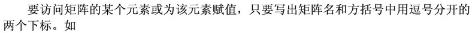

```r
## 提取
A[1, 2]
```

```
## [1] 4
```

```r
## 替换
A[1, 2] <- 104; A
```

```
##      [,1] [,2] [,3] [,4]
## [1,]    1  104    7   10
## [2,]    2    5    8   11
## [3,]    3    6    9   12
```

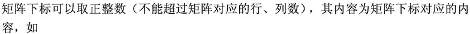

```r
## 提取
A[c(1, 3), 2:4]
```

```
##      [,1] [,2] [,3]
## [1,]  104    7   10
## [2,]    6    9   12
```

```r
## 替换
A[c(1, 3), 2:4] <- A[c(1, 3), 2:4] + 10; A
```

```
##      [,1] [,2] [,3] [,4]
## [1,]    1  114   17   20
## [2,]    2    5    8   11
## [3,]    3   16   19   22
```

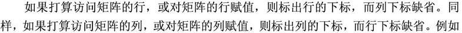

```r
## 提取
A[c(1, 3), ]
```

```
##      [,1] [,2] [,3] [,4]
## [1,]    1  114   17   20
## [2,]    3   16   19   22
```

```r
## 替换
A[2, ] <- 201:204; A
```

```
##      [,1] [,2] [,3] [,4]
## [1,]    1  114   17   20
## [2,]  201  202  203  204
## [3,]    3   16   19   22
```

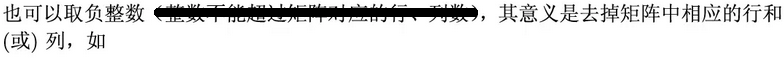

```r
A[-3, -2]
```

```
##      [,1] [,2] [,3]
## [1,]    1   17   20
## [2,]  201  203  204
```

```r
A[-1, ]
```

```
##      [,1] [,2] [,3] [,4]
## [1,]  201  202  203  204
## [2,]    3   16   19   22
```

```r
A[, -2]
```

```
##      [,1] [,2] [,3]
## [1,]    1   17   20
## [2,]  201  203  204
## [3,]    3   19   22
```

也可以使用逻辑下标。

```r
A < 100
```

```
##       [,1]  [,2]  [,3]  [,4]
## [1,]  TRUE FALSE  TRUE  TRUE
## [2,] FALSE FALSE FALSE FALSE
## [3,]  TRUE  TRUE  TRUE  TRUE
```

```r
A[A < 100] <- 100; A
```

```
##      [,1] [,2] [,3] [,4]
## [1,]  100  114  100  100
## [2,]  201  202  203  204
## [3,]  100  100  100  100
```

还有一种鲜为人知、但非常灵活的下标类型：双列矩阵。可用于不规则或自定义的元素操作。

```r
ij <- matrix(c(1, 2,
               2, 1,
               3, 4), nrow = 3, ncol = 2, byrow = TRUE)

## 提取
A[ij]
```

```
## [1] 114 201 100
```

```r
## 替换
A[ij] <- -A[ij]; A
```

```
##      [,1] [,2] [,3] [,4]
## [1,]  100 -114  100  100
## [2,] -201  202  203  204
## [3,]  100  100  100 -100
```

## 1.3.4-4 与方阵有关的函数

`diag`可以提取或替换一个方阵的对角线元素。

```r
S <- matrix(1:9, nrow = 3, ncol = 3); S
```

```
##      [,1] [,2] [,3]
## [1,]    1    4    7
## [2,]    2    5    8
## [3,]    3    6    9
```

```r
diag(S)
```

```
## [1] 1 5 9
```

```r
diag(S) <- diag(S) * 100
```

`upper.tri`和`lower.tri`可以生成上三角或下三角部分元素的逻辑值下标。

```r
upper.tri(S)
```

```
##       [,1]  [,2]  [,3]
## [1,] FALSE  TRUE  TRUE
## [2,] FALSE FALSE  TRUE
## [3,] FALSE FALSE FALSE
```

```r
upper.tri(S, diag = TRUE)
```

```
##       [,1]  [,2] [,3]
## [1,]  TRUE  TRUE TRUE
## [2,] FALSE  TRUE TRUE
## [3,] FALSE FALSE TRUE
```

```r
lower.tri(S)
```

```
##       [,1]  [,2]  [,3]
## [1,] FALSE FALSE FALSE
## [2,]  TRUE FALSE FALSE
## [3,]  TRUE  TRUE FALSE
```

```r
lower.tri(S, diag = TRUE)
```

```
##      [,1]  [,2]  [,3]
## [1,] TRUE FALSE FALSE
## [2,] TRUE  TRUE FALSE
## [3,] TRUE  TRUE  TRUE
```

将一个方阵的上三角、下三角元素清零，就得到了一个对角矩阵。

```r
S[upper.tri(S)] <- 0
S[lower.tri(S)] <- 0
S
```

```
##      [,1] [,2] [,3]
## [1,]  100    0    0
## [2,]    0  500    0
## [3,]    0    0  900
```

当然，如果你会使用`diag`，你会发现下面的捷径。

```r
diag(diag(S))
```

```
##      [,1] [,2] [,3]
## [1,]  100    0    0
## [2,]    0  500    0
## [3,]    0    0  900
```

如果想设置次对角线、反对角线、反上三角元素、反下三角元素（关于这些数学概念，参照附属内容），可以借助`row`和`col`函数生成逻辑矩阵作为下标，也可以直接定义双列矩阵作为下标（推荐方法）。

```r
## 下方次对角线的示例
S <- matrix(1:9, nrow = 3, ncol = 3); S
```

```
##      [,1] [,2] [,3]
## [1,]    1    4    7
## [2,]    2    5    8
## [3,]    3    6    9
```

```r
row(S) == col(S) + 1
```

```
##       [,1]  [,2]  [,3]
## [1,] FALSE FALSE FALSE
## [2,]  TRUE FALSE FALSE
## [3,] FALSE  TRUE FALSE
```

```r
S[row(S) == col(S) + 1] <- 0
S
```

```
##      [,1] [,2] [,3]
## [1,]    1    4    7
## [2,]    0    5    8
## [3,]    3    0    9
```

```r
## 上方次对角线的示例
S <- matrix(1:9, nrow = 3, ncol = 3); S
```

```
##      [,1] [,2] [,3]
## [1,]    1    4    7
## [2,]    2    5    8
## [3,]    3    6    9
```

```r
row(S) == col(S) - 1
```

```
##       [,1]  [,2]  [,3]
## [1,] FALSE  TRUE FALSE
## [2,] FALSE FALSE  TRUE
## [3,] FALSE FALSE FALSE
```

```r
S[row(S) == col(S) - 1] <- 0
S
```

```
##      [,1] [,2] [,3]
## [1,]    1    0    7
## [2,]    2    5    0
## [3,]    3    6    9
```

```r
## 反对角线的示例
S <- matrix(1:9, nrow = 3, ncol = 3); S
```

```
##      [,1] [,2] [,3]
## [1,]    1    4    7
## [2,]    2    5    8
## [3,]    3    6    9
```

```r
row(S) + col(S) == nrow(S) + 1
```

```
##       [,1]  [,2]  [,3]
## [1,] FALSE FALSE  TRUE
## [2,] FALSE  TRUE FALSE
## [3,]  TRUE FALSE FALSE
```

```r
S[row(S) + col(S) == nrow(S) + 1] <- 0
S
```

```
##      [,1] [,2] [,3]
## [1,]    1    4    0
## [2,]    2    0    8
## [3,]    0    6    9
```

```r
## 反三角示例一
S <- matrix(1:9, nrow = 3, ncol = 3); S
```

```
##      [,1] [,2] [,3]
## [1,]    1    4    7
## [2,]    2    5    8
## [3,]    3    6    9
```

```r
row(S) + col(S) < nrow(S) + 1  ## 没有anti.upper.tri()函数哦
```

```
##       [,1]  [,2]  [,3]
## [1,]  TRUE  TRUE FALSE
## [2,]  TRUE FALSE FALSE
## [3,] FALSE FALSE FALSE
```

```r
S[row(S) + col(S) < nrow(S) + 1] <- 0
S
```

```
##      [,1] [,2] [,3]
## [1,]    0    0    7
## [2,]    0    5    8
## [3,]    3    6    9
```

```r
## 反三角示例二
S <- matrix(1:9, nrow = 3, ncol = 3); S
```

```
##      [,1] [,2] [,3]
## [1,]    1    4    7
## [2,]    2    5    8
## [3,]    3    6    9
```

```r
row(S) + col(S) > nrow(S) + 1  ## 没有anti.lower.tri()函数哦
```

```
##       [,1]  [,2]  [,3]
## [1,] FALSE FALSE FALSE
## [2,] FALSE FALSE  TRUE
## [3,] FALSE  TRUE  TRUE
```

```r
S[row(S) + col(S) > nrow(S) + 1] <- 0
S
```

```
##      [,1] [,2] [,3]
## [1,]    1    4    7
## [2,]    2    5    0
## [3,]    3    0    0
```

## 1.3.4-5 `apply`函数

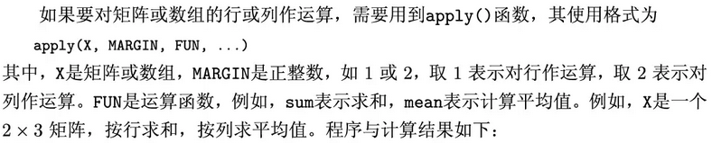

```r
X <- matrix(1:6, nrow = 2, ncol = 3)

## 其实rowSums(X)更好
apply(X, 1, sum)
```

```
## [1]  9 12
```

```r
## 其实colMeans(X)更好
apply(X, 2, mean)
```

```
## [1] 1.5 3.5 5.5
```

其实通过前面的学习，我们知道使用专门的`rowSums`, `colMeans`函数更好。但`apply`可以结合更一般的函数，比如：

```r
## 没有rowMins函数
apply(X, 1, min)
```

```
## [1] 1 2
```

```r
## 没有colMins函数
apply(X, 2, min)
```

```
## [1] 1 3 5
```

```r
## 没有colMaxs函数
apply(X, 1, max)
```

```
## [1] 5 6
```

```r
## 没有colMaxs函数
apply(X, 2, max)
```

```
## [1] 2 4 6
```

# 1.3.5 数组（跳过）

# 1.3.6 列表

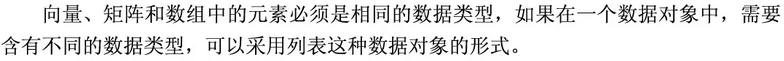

## 1.3.6-1 列表的构造

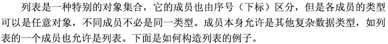

```r
Lst <- list("Fred", "Mary", 3, c(4, 7, 9),
            list(c("17 Oak Street", "Ottawa"),
                 c("289 Queen's Road", "Torronto")))
Lst
## [[1]]
## [1] "Fred"
##
## [[2]]
## [1] "Mary"
##
## [[3]]
## [1] 3
##
## [[4]]
## [1] 4 7 9
##
## [[5]]
## [[5]][[1]]
## [1] "17 Oak Street" "Ottawa"
##
## [[5]][[2]]
## [1] "289 Queen's Road" "Torronto"
```

```r
Lst[[2]]
```

```
## [1] "Mary"
```

```r
Lst[[4]][2]
```

```
## [1] 7
```

```r
Lst[[5]][[1]]
```

```
## [1] "17 Oak Street" "Ottawa"
```

```r
Lst[[5]][[1]][2]
```

```
## [1] "Ottawa"
```

```r
Lst[[1:2]]
```

```
## Error in Lst[[1:2]]: subscript out of bounds
```

`length`函数可以返回列表的成员个数。

```r
length(Lst)
```

```
## [1] 5
```

建议使用`str`函数查看列表的数据结构。

```r
str(Lst)
```

```
## List of 5
##  $ : chr "Fred"
##  $ : chr "Mary"
##  $ : num 3
##  $ : num [1:3] 4 7 9
##  $ :List of 2
##   ..$ : chr [1:2] "17 Oak Street" "Ottawa"
##   ..$ : chr [1:2] "289 Queen's Road" "Torronto"
```

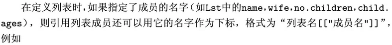

```r
Lst <- list(name = "Fred", wife = "Mary",
            no.children = 3, child.ages = c(4, 7, 9),
            home = list(address1 = c("17 Oak Street", "Ottawa"),
                        address2 = c("289 Queen's Road", "Torronto")))
Lst
```

```
## $name
## [1] "Fred"
##
## $wife
## [1] "Mary"
##
## $no.children
## [1] 3
##
## $child.ages
## [1] 4 7 9
##
## $home
## $home$address1
## [1] "17 Oak Street" "Ottawa"
##
## $home$address2
## [1] "289 Queen's Road" "Torronto"
```

```r
str(Lst)
```

```
## List of 5
##  $ name       : chr "Fred"
##  $ wife       : chr "Mary"
##  $ no.children: num 3
##  $ child.ages : num [1:3] 4 7 9
##  $ home       :List of 2
##   ..$ address1: chr [1:2] "17 Oak Street" "Ottawa"
##   ..$ address2: chr [1:2] "289 Queen's Road" "Torronto"
```

```r
Lst[["name"]]
```

```
## [1] "Fred"
```

```r
Lst[["child.ages"]]
```

```
## [1] 4 7 9
```

```r
Lst[["home"]][["address1"]]
```

```
## [1] "17 Oak Street" "Ottawa"
```

```r
Lst[["home"]][["address1"]][2]
```

```
## [1] "Ottawa"
```

```r
Lst$name
```

```
## [1] "Fred"
```

```r
Lst$child.ages
```

```
## [1] 4 7 9
```

```r
Lst$home$address1
```

```
## [1] "17 Oak Street" "Ottawa"
```

```r
Lst$home$address1[2]
```

```
## [1] "Ottawa"
```

不过，`$`和`[[]]`不是完全相同的。前者可以匹配成员名的起始部分，后者必须匹配完整的成员名。

```r
## 有效，child.age是child.ages的前几个字符
Lst$child.age
```

```
## [1] 4 7 9
```

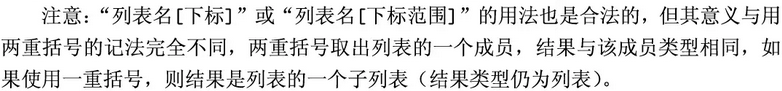

```r
## 无效，不存在名为child.age的成员，返回NULL（空）
Lst[["child.age"]]
## NULL
```

```r
Lst[2]
```

```
## $wife
## [1] "Mary"
```

```r
Lst[1:2]
```

```
## $name
## [1] "Fred"
##
## $wife
## [1] "Mary"
```

```r
Lst["wife"]
```

```
## $wife
## [1] "Mary"
```

```r
Lst[c("name", "wife")]
```

```
## $name
## [1] "Fred"
##
## $wife
## [1] "Mary"
```

## 1.3.6-2 列表的修改

```r
Lst$name <- "John"
Lst
```

```
## $name
## [1] "John"
##
## $wife
## [1] "Mary"
##
## $no.children
## [1] 3
##
## $child.ages
## [1] 4 7 9
##
## $home
## $home$address1
## [1] "17 Oak Street" "Ottawa"
##
## $home$address2
## [1] "289 Queen's Road" "Torronto"
```

```r
Lst$income <- c(1980, 1600)
Lst
```

```
## $name
## [1] "John"
##
## $wife
## [1] "Mary"
##
## $no.children
## [1] 3
##
## $child.ages
## [1] 4 7 9
##
## $home
## $home$address1
## [1] "17 Oak Street" "Ottawa"
##
## $home$address2
## [1] "289 Queen's Road" "Torronto"
##
##
## $income
## [1] 1980 1600
```

```r
Lst$home <- NULL
Lst
```

```
## $name
## [1] "John"
##
## $wife
## [1] "Mary"
##
## $no.children
## [1] 3
##
## $child.ages
## [1] 4 7 9
##
## $income
## [1] 1980 1600
```

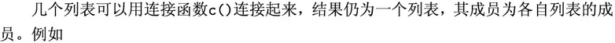

```r
## 假设我们有这样的两个列表
lstA <- Lst[1]
lstB <- Lst[2]

## 使用c函数拼接
c(lstA, lstB)
```

```
## $name
## [1] "John"
##
## $wife
## [1] "Mary"
```

注意：列表也可以用`list`来拼接，但`list(lstA, lstB)`和`c(lstA, lstB)`的效果是不同的。前者可以视为列表的“并联”，但后者是列表的“串联”。

## 1.3.6-3 参差不齐的数组与lapply和sapply函数

如果列表的成员是同类型、但长度不等的数值向量，该列表就是一个参差不齐的数组。

```r
rag <- list(a = 1:10, beta = exp(-3:3))
rag
```

```
## $a
##  [1]  1  2  3  4  5  6  7  8  9 10
##
## $beta
## [1]  0.04978707  0.13533528  0.36787944  1.00000000  2.71828183  7.38905610
## [7] 20.08553692
```

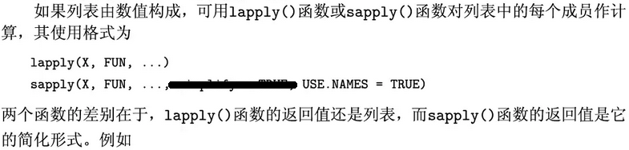

```r
lapply(rag, mean)
```

```
## $a
## [1] 5.5
##
## $beta
## [1] 4.535125
```

```r
sapply(rag, mean)
```

```
##        a     beta
## 5.500000 4.535125
```

我们可以使用`unlist`函数将各个成员向量合成一个向量。

```r
## 自动生成名字
unlist(rag)
```

```
##          a1          a2          a3          a4          a5          a6
##  1.00000000  2.00000000  3.00000000  4.00000000  5.00000000  6.00000000
##          a7          a8          a9         a10       beta1       beta2
##  7.00000000  8.00000000  9.00000000 10.00000000  0.04978707  0.13533528
##       beta3       beta4       beta5       beta6       beta7
##  0.36787944  1.00000000  2.71828183  7.38905610 20.08553692
```

```r
## 忽略名字
unlist(rag, use.names = FALSE)
```

```
##  [1]  1.00000000  2.00000000  3.00000000  4.00000000  5.00000000  6.00000000
##  [7]  7.00000000  8.00000000  9.00000000 10.00000000  0.04978707  0.13533528
## [13]  0.36787944  1.00000000  2.71828183  7.38905610 20.08553692
```

```r
## 这里和sapply(rag, mean)的效果一样
unlist(lapply(rag, mean))
```

```
##        a     beta
## 5.500000 4.535125
```

# 1.3.7 数据框

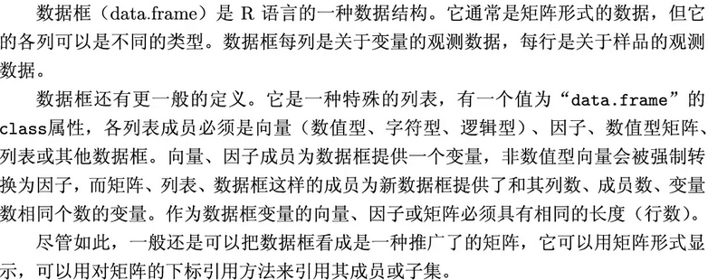

## 1.3.7-1 数据框的生成

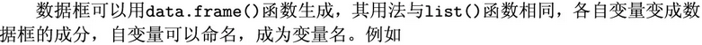

```r
df <- data.frame(Name = c("Alice", "Becka", "James", "Jeffrey", "John"),
                 Sex = c("F", "F", "M", "M", "M"),
                 Age = c(13, 13, 12, 13, 12),
                 Height = c(56.5, 65.3, 57.3, 62.5, 59.0),
                 Weight = c(84.0, 98.0, 83.0, 84.0, 99.5))
df
```

```
##      Name Sex Age Height Weight
## 1   Alice   F  13   56.5   84.0
## 2   Becka   F  13   65.3   98.0
## 3   James   M  12   57.3   83.0
## 4 Jeffrey   M  13   62.5   84.0
## 5    John   M  12   59.0   99.5
```

和list一样，建议使用`str`函数查看数据结构。

```r
str(df)
```

```
## 'data.frame':    5 obs. of  5 variables:
##  $ Name  : chr  "Alice" "Becka" "James" "Jeffrey" ...
##  $ Sex   : chr  "F" "F" "M" "M" ...
##  $ Age   : num  13 13 12 13 12
##  $ Height: num  56.5 65.3 57.3 62.5 59
##  $ Weight: num  84 98 83 84 99.5
```

## 1.3.7-2 数据框的引用

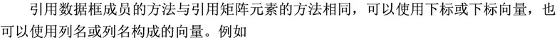

```r
df[1:2, 3:5]
```

```
##   Age Height Weight
## 1  13   56.5     84
## 2  13   65.3     98
```

```r
df[1:2, c("Age", "Height", "Weight")]
```

```
##   Age Height Weight
## 1  13   56.5     84
## 2  13   65.3     98
```

```r
df[1:2, ]
```

```
##    Name Sex Age Height Weight
## 1 Alice   F  13   56.5     84
## 2 Becka   F  13   65.3     98
```

```r
df[, 3:5]
```

```
##   Age Height Weight
## 1  13   56.5   84.0
## 2  13   65.3   98.0
## 3  12   57.3   83.0
## 4  13   62.5   84.0
## 5  12   59.0   99.5
```

```r
df[, c("Age", "Height", "Weight")]
```

```
##   Age Height Weight
## 1  13   56.5   84.0
## 2  13   65.3   98.0
## 3  12   57.3   83.0
## 4  13   62.5   84.0
## 5  12   59.0   99.5
```

```r
df[[4]]
```

```
## [1] 56.5 65.3 57.3 62.5 59.0
```

```r
df[["Height"]]
```

```
## [1] 56.5 65.3 57.3 62.5 59.0
```

```r
df$Height
```

```
## [1] 56.5 65.3 57.3 62.5 59.0
```

如果只引用一列，但还希望结果是一个数据框，则使用`[]`.

```r
df[4]
```

```
##   Height
## 1   56.5
## 2   65.3
## 3   57.3
## 4   62.5
## 5   59.0
```

```r
df["Height"]
```

```
##   Height
## 1   56.5
## 2   65.3
## 3   57.3
## 4   62.5
## 5   59.0
```

如果提取多列，则既可以按照矩阵的句法用`[, ]`操作，也可以按照列表的句法用`[]`操作。

```r
df[, 3:5]
```

```
##   Age Height Weight
## 1  13   56.5   84.0
## 2  13   65.3   98.0
## 3  12   57.3   83.0
## 4  13   62.5   84.0
## 5  12   59.0   99.5
```

```r
df[3:5]
```

```
##   Age Height Weight
## 1  13   56.5   84.0
## 2  13   65.3   98.0
## 3  12   57.3   83.0
## 4  13   62.5   84.0
## 5  12   59.0   99.5
```

```r
df[, c("Age", "Height", "Weight")]
```

```
##   Age Height Weight
## 1  13   56.5   84.0
## 2  13   65.3   98.0
## 3  12   57.3   83.0
## 4  13   62.5   84.0
## 5  12   59.0   99.5
```

```r
df[c("Age", "Height", "Weight")]
```

```
##   Age Height Weight
## 1  13   56.5   84.0
## 2  13   65.3   98.0
## 3  12   57.3   83.0
## 4  13   62.5   84.0
## 5  12   59.0   99.5
```

需要特别注意的是，`:`（范围运算）和`-`（剔除运算）只对数字合法，而对列名非法。(使用下面要介绍的`subset`函数可以优雅地避开这个问题。)

```r
df[, -c("Age", "Height", "Weight")]
```

```
## Error in -c("Age", "Height", "Weight"): invalid argument to unary operator
```

```r
df[-c("Age", "Height", "Weight")]
```

```
## Error in -c("Age", "Height", "Weight"): invalid argument to unary operator
```

## 1.3.7-3 使用`subset`函数进行引用

数据框的引用除了使用方括号，还可以使用`subset`函数。

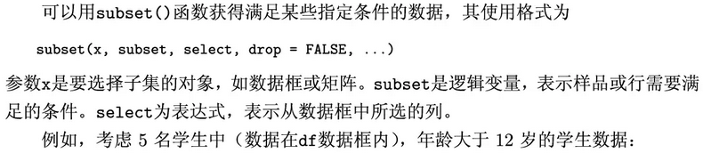

```r
subset(df, Age > 12)
```

```
##      Name Sex Age Height Weight
## 1   Alice   F  13   56.5     84
## 2   Becka   F  13   65.3     98
## 4 Jeffrey   M  13   62.5     84
```

```r
## 使用列名
subset(df, Sex == "F", select = Age:Weight)
```

```
##   Age Height Weight
## 1  13   56.5     84
## 2  13   65.3     98
```

```r
## 使用列数
subset(df, Sex == "F", select = 3:5)
```

```
##   Age Height Weight
## 1  13   56.5     84
## 2  13   65.3     98
```

可以断断续续地选择一些列。

```r
## 使用列名
subset(df, Sex == "F", select = c(Age, Weight))
```

```
##   Age Weight
## 1  13     84
## 2  13     98
```

```r
## 使用列数
subset(df, Sex == "F", select = c(3, 5))
```

```
##   Age Weight
## 1  13     84
## 2  13     98
```

也可以反向操作，剔除一些列。

```r
## 使用列名，注意，括号是必须的！
subset(df, Sex == "F", select = -(Age:Weight))
```

```
##    Name Sex
## 1 Alice   F
## 2 Becka   F
```

```r
## 使用列数
subset(df, Sex == "F", select = -(3:5))
```

```
##    Name Sex
## 1 Alice   F
## 2 Becka   F
```

```r
## 使用列名
subset(df, Sex == "F", select = -c(Age, Weight))
```

```
##    Name Sex Height
## 1 Alice   F   56.5
## 2 Becka   F   65.3
```

```r
## 使用列数
subset(df, Sex == "F", select = -c(3, 5))
```

```
##    Name Sex Height
## 1 Alice   F   56.5
## 2 Becka   F   65.3
```

要特别注意两点：

（1）`subset`参数必须是与行数相同的逻辑向量，给数值是非法的。

```r
subset(df, 1:2)
```

```
## Error in subset.data.frame(df, 1:2): 'subset' must be logical
```

2. `select`参数在使用列名式，不要画蛇添足，给列名加引号，多数时候是会出错的哦～

```r
## 正确用法：subset(df, Sex == "F", select = Age:Weight)
subset(df, Sex == "F", select = "Age":"Weight")
## Warning in eval(substitute(select), nl, parent.frame()): NAs introduced by
## coercion
## Error in "Age":"Weight": NA/NaN argument

## OK，但推荐使用：subset(df, Sex == "F", select = c(Age, Weight))
subset(df, Sex == "F", select = c("Age", "Weight"))
```

```
##   Age Weight
## 1  13     84
## 2  13     98
```

```r
## 正确用法：subset(df, Sex == "F", select = -(Age:Weight))
subset(df, Sex == "F", select = -("Age":"Weight"))
## Warning in eval(substitute(select), nl, parent.frame()): NAs introduced by
## coercion
## Error in "Age":"Weight": NA/NaN argument

## 正确用法：subset(df, Sex == "F", select = -c(Age, Weight))
subset(df, Sex == "F", select = -c("Age", "Weight"))
```

```
## Error in -c("Age", "Weight"): invalid argument to unary operator
```

## 1.3.7-4 `with`函数

对成员执行操作时，为避免反复使用`$`或者`[[]]`，可以使用`with`函数。

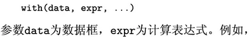

```r
df$r <- df$Height / df$Weight

df$r <- with(df, Height / Weight)
```

再看一个更复杂的例子。

```r
## 将字符串转为因子变量
df$fSex <- factor(df$Sex, levels = c("M", "F"))
str(df)
```

```
## 'data.frame':    5 obs. of  7 variables:
##  $ Name  : chr  "Alice" "Becka" "James" "Jeffrey" ...
##  $ Sex   : chr  "F" "F" "M" "M" ...
##  $ Age   : num  13 13 12 13 12
##  $ Height: num  56.5 65.3 57.3 62.5 59
##  $ Weight: num  84 98 83 84 99.5
##  $ r     : num  0.673 0.666 0.69 0.744 0.593
##  $ fSex  : Factor w/ 2 levels "M","F": 2 2 1 1 1
```

```r
## 男、女学生的平均体重
with(df, tapply(Weight, fSex, mean))
```

```
##        M        F
## 88.83333 91.00000
```

```r
## 男、女学生的平均身高
with(df, tapply(Height, fSex, mean))
```

```
##    M    F
## 59.6 60.9
```

## 1.3.7-5 行名、列名

可以像操作矩阵一样，操作数据框的行名、列名。但比较独特的是，数据框的行名不能为空（NULL）。设定成NULL只是将行名重置为1, 2, 3, …而已。

```r
dimnames(df)
## [[1]]
## [1] "1" "2" "3" "4" "5"
##
## [[2]]
## [1] "Name"   "Sex"    "Age"    "Height" "Weight" "r"      "fSex"

colnames(df)
```

```
## [1] "Name"   "Sex"    "Age"    "Height" "Weight" "r"      "fSex"
```

```r
## 修改行名
rownames(df) <- letters[1:5]
df
```

```
##      Name Sex Age Height Weight         r fSex
## a   Alice   F  13   56.5   84.0 0.6726190    F
## b   Becka   F  13   65.3   98.0 0.6663265    F
## c   James   M  12   57.3   83.0 0.6903614    M
## d Jeffrey   M  13   62.5   84.0 0.7440476    M
## e    John   M  12   59.0   99.5 0.5929648    M
```

```r
## 重置
rownames(df) <- NULL
df
```

```
##      Name Sex Age Height Weight         r fSex
## 1   Alice   F  13   56.5   84.0 0.6726190    F
## 2   Becka   F  13   65.3   98.0 0.6663265    F
## 3   James   M  12   57.3   83.0 0.6903614    M
## 4 Jeffrey   M  13   62.5   84.0 0.7440476    M
## 5    John   M  12   59.0   99.5 0.5929648    M
```

## 1.3.7-6 像处理list一样使用`lapply`和`sapply`函数

很重要的一个命令：查看数据框各列的数据类型。

```r
class(df)
```

```
## [1] "data.frame"
```

```r
sapply(df, class)
```

```
##        Name         Sex         Age      Height      Weight           r
## "character" "character"   "numeric"   "numeric"   "numeric"   "numeric"
##        fSex
##    "factor"
```

## 1.3.7-7 将数据框转为矩阵

数据框中，类型相同的列可以取出来，转存为矩阵。

```r
## 字符串、因子可以拿出来存成一个字符串矩阵
df[c(1:2, 7)]
```

```
##      Name Sex fSex
## 1   Alice   F    F
## 2   Becka   F    F
## 3   James   M    M
## 4 Jeffrey   M    M
## 5    John   M    M
```

```r
as.matrix(df[c(1:2, 7)])
```

```
##      Name      Sex fSex
## [1,] "Alice"   "F" "F"
## [2,] "Becka"   "F" "F"
## [3,] "James"   "M" "M"
## [4,] "Jeffrey" "M" "M"
## [5,] "John"    "M" "M"
```

```r
## 数值列可以拿出来存成一个数值矩阵
df[3:6]
```

```
##   Age Height Weight         r
## 1  13   56.5   84.0 0.6726190
## 2  13   65.3   98.0 0.6663265
## 3  12   57.3   83.0 0.6903614
## 4  13   62.5   84.0 0.7440476
## 5  12   59.0   99.5 0.5929648
```

```r
as.matrix(df[3:6])
```

```
##      Age Height Weight         r
## [1,]  13   56.5   84.0 0.6726190
## [2,]  13   65.3   98.0 0.6663265
## [3,]  12   57.3   83.0 0.6903614
## [4,]  13   62.5   84.0 0.7440476
## [5,]  12   59.0   99.5 0.5929648
```

如果数据框各列类型不统一，将数据框整体转存为矩阵是危险的，一些列的类型会被转换。

```r
## 原来的数值列也都变成字符串列啦！
as.matrix(df)
```

```
##      Name      Sex Age  Height Weight r           fSex
## [1,] "Alice"   "F" "13" "56.5" "84.0" "0.6726190" "F"
## [2,] "Becka"   "F" "13" "65.3" "98.0" "0.6663265" "F"
## [3,] "James"   "M" "12" "57.3" "83.0" "0.6903614" "M"
## [4,] "Jeffrey" "M" "13" "62.5" "84.0" "0.7440476" "M"
## [5,] "John"    "M" "12" "59.0" "99.5" "0.5929648" "M"
```

## 1.3.7-8 数据框的陷阱

数据框的最大陷阱，是它在打印时不对字符串显示引号，不对因子显示水平。

```r
df
```

```
##      Name Sex Age Height Weight         r fSex
## 1   Alice   F  13   56.5   84.0 0.6726190    F
## 2   Becka   F  13   65.3   98.0 0.6663265    F
## 3   James   M  12   57.3   83.0 0.6903614    M
## 4 Jeffrey   M  13   62.5   84.0 0.7440476    M
## 5    John   M  12   59.0   99.5 0.5929648    M
```

```r
## 单独提出来看，有引号
df$Sex
```

```
## [1] "F" "F" "M" "M" "M"
```

```r
## 单独提出来看，有水平
df$fSex
```

```
## [1] F F M M M
## Levels: M F
```

所以我们来看这样一个数据框。

```r
DF <- data.frame(x = as.character(1:4), y = factor(1:4), z = 1:4)

## 各列类型不一样
sapply(DF, class)
```

```
##           x           y           z
## "character"    "factor"   "integer"
```

```r
## 直接打印，貌似都是数值列
DF
```

```
##   x y z
## 1 1 1 1
## 2 2 2 2
## 3 3 3 3
## 4 4 4 4
```

```r
## 直接转成矩阵，就发生意外了
as.matrix(DF)
```

```
##      x   y   z
## [1,] "1" "1" "1"
## [2,] "2" "2" "2"
## [3,] "3" "3" "3"
## [4,] "4" "4" "4"
```

之所以说这是一个陷阱，是因为它很多时候会给我们造成困扰。

```r
sapply(DF, mean)
## Warning in mean.default(X[[i]], ...): argument is not numeric or logical:
## returning NA
##   x   y   z
##  NA  NA 2.5

apply(DF, 2, mean)
## Warning in mean.default(newX[, i], ...): argument is not numeric or logical:
## returning NA
##  x  y  z
## NA NA NA

colMeans(DF)
```

```
## Error in colMeans(DF): 'x' must be numeric
```

所以，不要仅凭一个数据框打印出来的样子就判断各列的类型；一定要用`sapply(, class)`去核实。

# 作业

1. [不提交] 在上机课上运行本课所有代码；
2. [提交] 课本55页，第7、8、9、10、12题。

# 附属内容

上方次对角线

$$\begin{equation}
\begin{bmatrix}
\circ & \times & \circ & \circ\\
\circ & \circ & \times & \circ\\
\circ & \circ & \circ & \times\\
\circ & \circ & \circ & \circ
\end{bmatrix}
\end{equation}$$

下方次对角线

$$\begin{equation}
\begin{bmatrix}
\circ & \circ & \circ & \circ\\
\times & \circ & \circ & \circ\\
\circ & \times & \circ & \circ\\
\circ & \circ & \times & \circ\\
\end{bmatrix}
\end{equation}$$

反对角线

$$\begin{equation}
\begin{bmatrix}
\circ & \circ & \circ & \times\\
\circ & \circ & \times & \circ\\
\circ & \times & \circ & \circ\\
\times & \circ & \circ & \circ\\
\end{bmatrix}
\end{equation}$$

上方次反对角线

$$\begin{equation}
\begin{bmatrix}
\circ & \circ & \times & \circ\\
\circ & \times & \circ & \circ\\
\times & \circ & \circ & \circ\\
\circ & \circ & \circ & \circ\\
\end{bmatrix}
\end{equation}$$

下方次反对角线

$$\begin{equation}
\begin{bmatrix}
\circ & \circ & \circ & \circ\\
\circ & \circ & \circ & \times\\
\circ & \circ & \times & \circ\\
\circ & \times & \circ & \circ\\
\end{bmatrix}
\end{equation}$$

反上三角

$$\begin{equation}
\begin{bmatrix}
\times & \times & \times & \circ\\
\times & \times & \circ & \circ\\
\times & \circ & \circ & \circ\\
\circ & \circ & \circ & \circ\\
\end{bmatrix}
\end{equation}$$

反下三角

$$\begin{equation}
\begin{bmatrix}
\circ & \circ & \circ & \circ\\
\circ & \circ & \circ & \times\\
\circ & \circ & \times & \times\\
\circ & \times & \times & \times\\
\end{bmatrix}
\end{equation}$$

返回所在小节。